# R-Lab: Decision Trees

```r
require(mlbench)
require(rpart)
library(help = "datasets")

data(library(help = "datasets"))

# example of entropy
p <- 4/6
e0 <- -p * log2(p) - (1 - p) * log2(1 - p)
e1 <- -2/3 * log2(2/3) - 1/3 * log2(1/3)
e0 - 0.5 * e1
```

```
## [1] 0.4591479
```

```r
# pruning
estimate <- function(e, n) {
    return(e + 1.15 * sqrt(e * (1 - e)/n))
}
estimate(1, 2)
```

```
## [1] 1
```

```r
a <- estimate(9/19, 19) * 19
b <- estimate(9/20, 20) * 20
estimate(19/39, 39) * 39
```

```
## [1] 22.58969
```

```r
a + b
```

```
## [1] 23.06148
```

```r
estimate(2/12, 12) * 12
```

```
## [1] 3.484644
```

```r
estimate(21/51, 51) * 51
```

```
## [1] 25.04188
```

```r
estimate(0/10, 10) * 10
```

```
## [1] 0
```

```r
estimate(19/49, 49) * 49
```

```
## [1] 22.92227
```

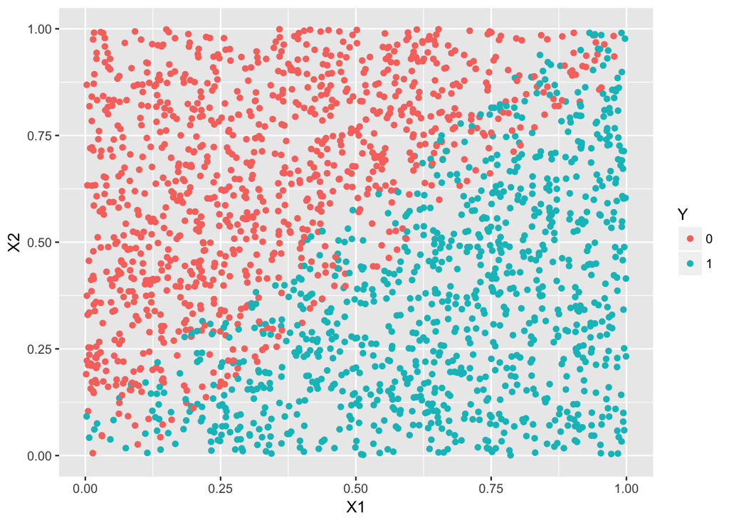

```r
# comparison between Decision tree and regression model
require(rpart)
require(dplyr)
require(ggplot2)
ndata <- 2000
X1 <- runif(ndata, min = 0, max = 1)
X2 <- runif(ndata, min = 0, max = 1)
data <- data.frame(X1, X2)
data <- data %>% mutate(X12 = 0.5 * (X1 - X2), Y = ifelse(X12 >= 0, 1, 0))
ix <- which(abs(data$X12) <= 0.05)
data$Y[ix] <- ifelse(runif(length(ix)) < 0.5, 0, 1)
data <- data %>% select(-X12) %>% mutate(Y = as.factor(as.character(Y)))
ggplot(data, aes(x = X1, y = X2, color = Y)) + geom_point()
```

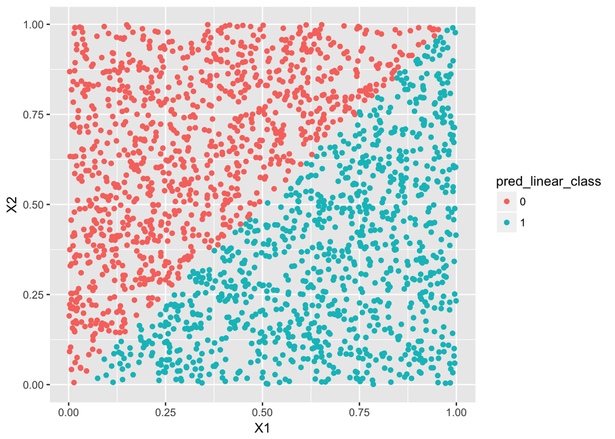

```r
linear_model <- glm(Y ~ ., family = binomial(link = "logit"), data = data)
tree_model <- rpart(Y ~ ., data = data)
pred_linear <- predict(linear_model, data, type = "response")
pred_tree <- predict(tree_model, data, type = "prob")[, 1]
data_pred <- data %>% mutate(pred_linear_class = ifelse(pred_linear < 0.5, 0,
    1)) %>% mutate(pred_linear_class = as.factor(as.character(pred_linear_class))) %>%
    mutate(pred_tree_class = ifelse(pred_tree < 0.5, 0, 1)) %>% mutate(pred_tree_class = as.factor(as.character(pred_tree_class)))
ggplot(data_pred, aes(x = X1, y = X2, color = pred_linear_class)) + geom_point()
```

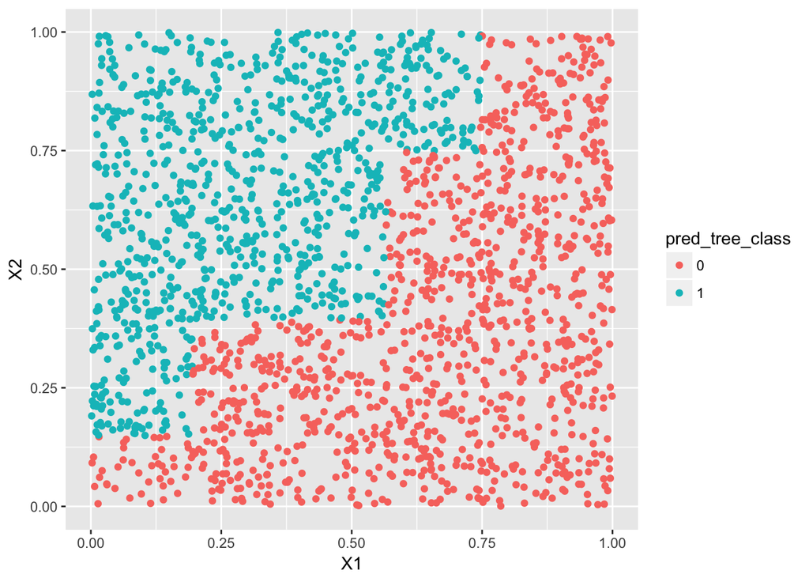

```r
ggplot(data_pred, aes(x = X1, y = X2, color = pred_tree_class)) + geom_point()
```

## R-lab

Here we use DX_bl as the target variable, and use variables other than ID, TOTAL13 and MMSCORE to predict DX_bl. Since DX_bl is binary, so this can considered as a classification problem.

```r
library(rpart)
library(rpart.plot)
library(dplyr)
library(tidyr)
library(ggplot2)
library(RCurl)
library(partykit)
theme_set(theme_gray(base_size = 15))


data <- read.csv(text = getURL("https://raw.githubusercontent.com/shuailab/ind_498/master/resource/data/AD.csv"))

target_indx <- which(colnames(data) == "DX_bl")
data[, target_indx] <- as.factor(paste0("c", data[, target_indx]))
rm_indx <- which(colnames(data) %in% c("ID", "TOTAL13", "MMSCORE"))
data <- data[, -rm_indx]
```

Apply a decision tree to the data and plot the decision tree.

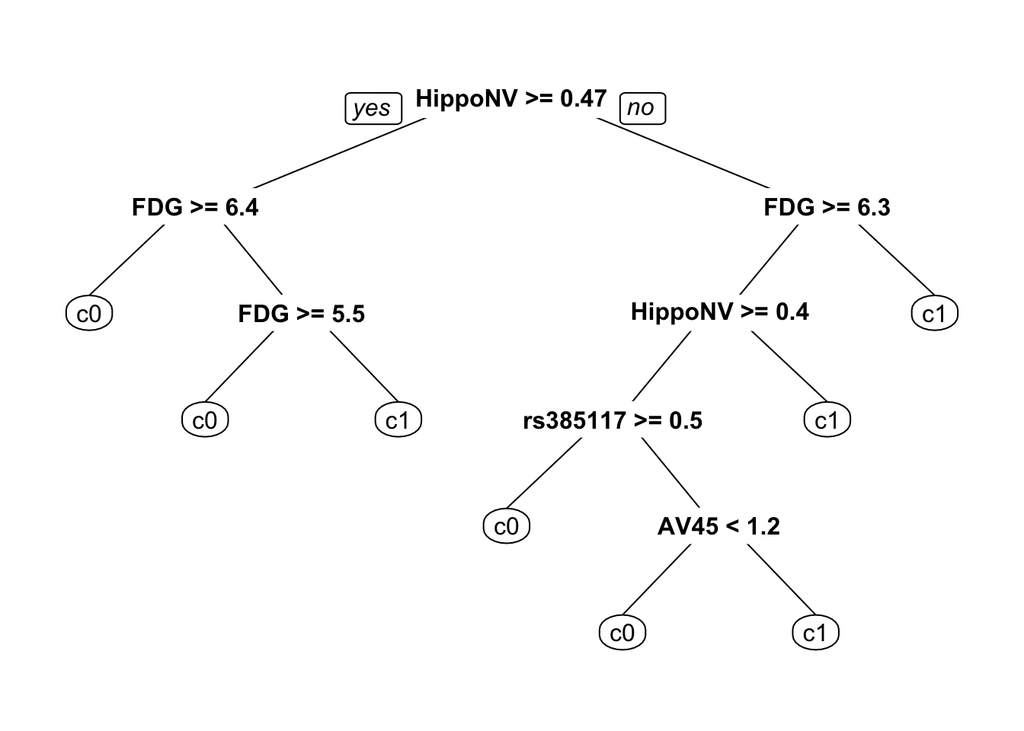

```r
tree <- rpart(DX_bl ~ ., data)
# rpart.plot(tree,fallen.leaves=FALSE,type=0,xcompact=TRUE,compact=TRUE)
prp(tree, nn.cex = 1)
```

The importance score for each variable can be obtained from the tree. HippoNV has the largest importance score among all variables.

```r
print(tree$variable.importance)
```

```
##     HippoNV         FDG        AV45         AGE    PTGENDER        e4_1
## 116.6665538  89.5608444  39.9595988  28.2195180  12.2040648   6.4708596
##   rs3851179    PTEDUCAT   rs3818361
##   4.2352941   1.1552265   0.8663915
```

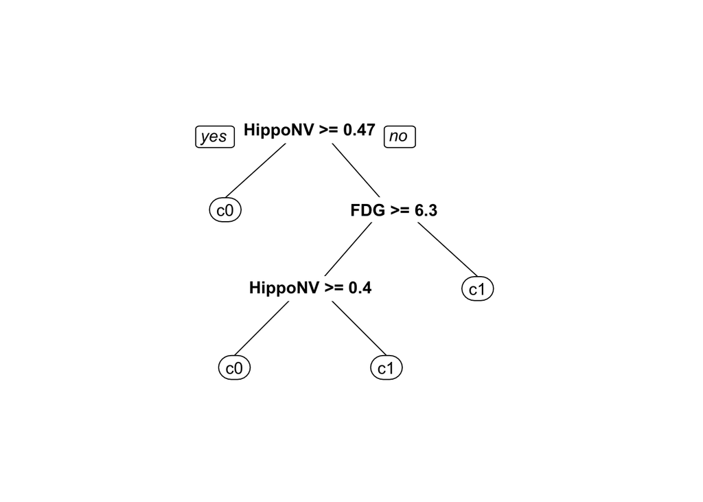

```r
tree_0.05 <- prune(tree, cp = 0.05)
# rpart.plot(tree_0.05,fallen.leaves=FALSE)
prp(tree_0.05, nn.cex = 1)
```

Then we increase cp to 0.1. The tree only has two nodes. Here we demonstrate the pruning process by using parameter cp. In practicse, cp can be decided by minimizing the cross-validation error.

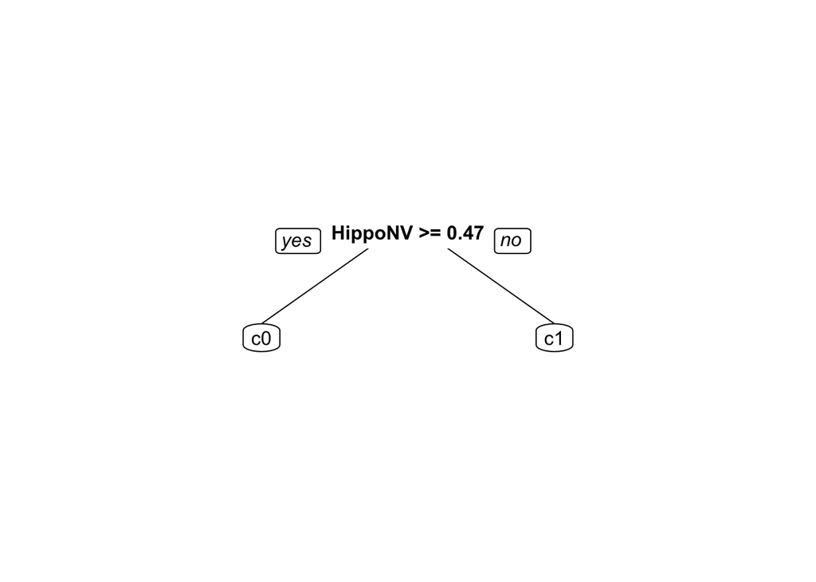

```r
tree_0.1 <- prune(tree, cp = 0.1)
# rpart.plot(tree_0.1,fallen.leaves=FALSE)
prp(tree_0.1, nn.cex = 1)
```

```r
set.seed(1)
train.ix <- sample(nrow(data), floor(nrow(data)/2))
err.train.v <- NULL
err.test.v <- NULL
leaf.v <- NULL
for (i in seq(0.2, 0, by = -0.005)) {
    tree <- rpart(DX_bl ~ ., data = data[train.ix, ], cp = i)
    pred.train <- predict(tree, data[train.ix, ], type = "class")
    pred.test <- predict(tree, data[-train.ix, ], type = "class")
    current.err.train <- length(which(pred.train != data[train.ix, ]$DX_bl))/length(pred.train)
    current.err.test <- length(which(pred.test != data[-train.ix, ]$DX_bl))/length(pred.test)
    err.train.v <- c(err.train.v, current.err.train)
    err.test.v <- c(err.test.v, current.err.test)
    leaf.v <- c(leaf.v, length(which(tree$frame$var == "<leaf>")))
}
err.mat <- as.data.frame(cbind(train_err = err.train.v, test_err = err.test.v,
    leaf_num = leaf.v))
err.mat$leaf_num <- as.factor(err.mat$leaf_num)
err.mat <- unique(err.mat)
err.mat <- err.mat %>% gather(type, error, train_err, test_err)
```

The training errors and testing errors of the trees at different number of leaf nodes are plotted. It can be seen that, as the complexity of trees increases, the training errors continue to decrease, while the testing errors first decrease but increase at some point. This indicates that testing error should be used for measuring a decision tree as minimizing the training error can lead to overfitting.

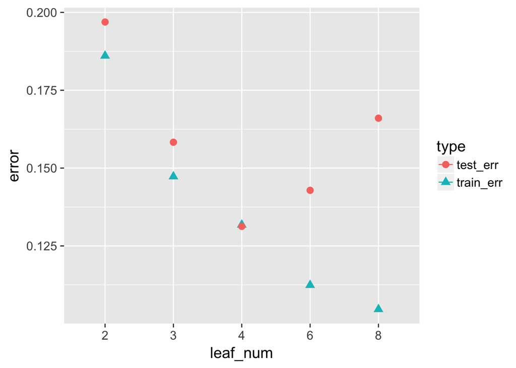

```r
data.plot <- err.mat %>% mutate(type = factor(type))
ggplot(data.plot, aes(x = leaf_num, y = error, shape = type, color = type)) +
    geom_line() + geom_point(size = 3)
```

[output not shown]